# Лабораторная работа №5.1.2

## Теоретическая справка

### Виды взаимодействия $\gamma$- кванта с веществом

При прохождении $\gamma$-излучения через вещество происходит ослабление интенсивности пучка $\gamma$-квантов, что является результатом их взаимодействия с атомами вещества.

#### Фотоэффект

При фотоэффекте из атома выбивается электрон, а квант поглощается. Импульс кванта делится между вылетевшим электроном и атомом, а его энергия частично передается электрону, а частично тратится на возбуждение атома. Атом практически мгновенно (за время порядка $10^{-8}с$) возвращается в нормальное состояние. Его энергия возбуждения излучается в виде мягкого фотона, либо передется какому-нибудь другому электрону, который покидает атом (Оже-эффект). Энергия кванта должна быть больше энергии связи электрона оболочки атома.

#### Томпсоновское рассеяние

Рассеяние квантов не очень высокой энергии. В этом случае атом воспринимается фотоном "как единое целое", и фотон обменивается энергией и импульсом со всем атомом. Так как масса атома очень велика по сравнению с эквивалентной массой фотона $\frac{h\nu}{c}$ , то отдача в этом случае практически отсутствует. Поэтому рассеяние фотонов происходит без изменения их энергии, т.е. когерентно.

#### Комптоновское рассеяние

При комптоновском рассеянии каждый электрон атома ведет себя независимо от других, поскольку рассеяние в этом случае происходитна каком-либо одном из атомных электронов.

#### Образование электронно нейтральных пар

При достаточно большой энергии ($\gamma$-квантов $2mc^2 = 1.02$МэВ) становится возможным процесс образования пары, при котором в поле ядра фотон поглощается, и рождаются электрон и позитрон. В рассматриваемом энергетическом диапозоне не наблюдается.

[figure not shown]

Рис. 1. Сечение взаимодействия фотонов с углеродом (Z = 6) и свинцом (Z = 82) при энергиях фотона от 10 эВ до 100 ГэВ. $\sigma_{ph}$ - сечение фотоэффекта, $\sigma_{coh}$ - сечение релеевского рассеяния, $\sigma_{ph}$ - сечение комптоновского рассеяния, $\sigma_{np}$ - сечение рождения пары в поле ядра, $\sigma_{ep}$ - сечение образования пар в поле атомных электронов, $\sigma_{GDR}$ - сечении ядерного фотопоглощения.

### Фотоэлектронный умножитель

Фотоэлементы, основанные на эффекте фотоэффекта, не позволяют измерять слабые световые потоки, так как фототок получается ничтожно малым. Фотоэлектронный умножитель позволяет усиливать фототок в огромное число раз. Бомбардировка поверхности вызывает металла вызывает эмиссию вторичных электронов с облучаемой поверхности. Количество выбитых может быть больше количества падающих. Эмиссионный свойства характеризуются величиной $\sigma = \frac{n_2}{n_1}$, где $n_2$ - число выбитых, а $n_1$ - число падающих электронов. Величина $\sigma$ зависит от энергии падающих электронов, температуры слоя, толщины, угла падения и т.д. Со временем $\sigma$ может меняться.

[figure not shown]

### Кристаллический сцинтиллятор NaI(Tl)

В непроводящих чистых неорганических кристаллах электроны в основном состоянии расположены в валентной зоне А. Проходя через кристалл, заряженная частица переводит часть электронов из основного состояния в возбужденное, в зону проводимости В. При диффузии в зоне проводимости электрон может оказаться вблизи свободного уровня валентной зоны - "дырки". Если происходит рекомбинация электрона с "дыркой", то излучаются световые кванты с энергией, определяемой шириной запрещенной зоны кристалла - С. Этой же шириной определяется и спектр поглощения кристалла. Поэтому излученные при рекомбинации световые кванты интенсивно поглощаются внутри и свет наружу не выходит.

[figure not shown]

## Обработка результатов

[figure not shown]

$N_{наил}(0) = 913.686262867$

$N_{наил}(90) = 395.357272769$

$E_\gamma = 662 кэВ$

$mc^2 = 504.942844357 кэВ$

## Вывод

На основании теоретических выкладок из эксперимента получили значение энергии покоя частицы, на которой происходит отклонение гамма-квантов – электроны 505 КэВ.

```python
from matplotlib import pyplot as plt
import numpy as np
import pandas as pd
from scipy import poly1d
%matplotlib inline
```

```python
# Загрузим данные
data = pd.read_csv('dataset.txt', header=None, sep=' ')
data.columns=('$%s,\ %s$'%(r'\theta', 'град.'), '$%s, %s\ %s$'%(u'N', u'номер',u'канала'), '$%s$'%r'Счет', '$%s$'%u'Время', '$%s$'%u'Частиц')
```

```python
# Дополним таблицу вспомогательными данными
data[u'$\\frac{1}{N}$'] = [1./x for x in data[data.columns[1]]]
data[u'$1 - \cos$' + '$\\theta$'] = [1. - np.cos(x*1.0/180*np.pi) for x in data[data.columns[0]]]
data[u'$\sigma_\\frac{1}{N}$'] = [x**(-1.5) for x in data[data.columns[1]]]
display(data)
```

|  | $\theta,\ град.$ | $N, номер\ канала$ | $Счет$ | $Время$ | $Частиц$ | $\frac{1}{N}$ | $1 - \cos$$\theta$ | $\sigma_\frac{1}{N}$ |
| --- | --- | --- | --- | --- | --- | --- | --- | --- |
| 0 | 0 | 968 | 48389 | 63 | 496698 | 0.001033 | 0.000000 | 0.000033 |
| 1 | 10 | 892 | 184781 | 249 | 1662281 | 0.001121 | 0.015192 | 0.000038 |
| 2 | 20 | 826 | 64742 | 188 | 127348 | 0.001211 | 0.060307 | 0.000042 |
| 3 | 30 | 773 | 46800 | 173 | 75751 | 0.001294 | 0.133975 | 0.000047 |
| 4 | 40 | 713 | 43475 | 189 | 66609 | 0.001403 | 0.233956 | 0.000053 |
| 5 | 50 | 628 | 49924 | 231 | 76524 | 0.001592 | 0.357212 | 0.000064 |
| 6 | 60 | 546 | 39615 | 215 | 57504 | 0.001832 | 0.500000 | 0.000078 |
| 7 | 70 | 485 | 41732 | 239 | 58773 | 0.002062 | 0.657980 | 0.000094 |
| 8 | 80 | 429 | 41860 | 245 | 57477 | 0.002331 | 0.826352 | 0.000113 |
| 9 | 90 | 391 | 32881 | 199 | 45469 | 0.002558 | 1.000000 | 0.000129 |
| 10 | 100 | 360 | 33513 | 206 | 46373 | 0.002778 | 1.173648 | 0.000146 |
| 11 | 110 | 333 | 136860 | 835 | 196759 | 0.003003 | 1.342020 | 0.000165 |
| 12 | 120 | 312 | 75372 | 487 | 107561 | 0.003205 | 1.500000 | 0.000181 |

```python
# Проведем линейную аппроксимацию
x = data[data.columns[-2]]
y = data[data.columns[-3]]
yerr = data[data.columns[-1]]
xerr = (1-np.cos(1/180*np.pi))*np.ones(13)
A = np.vstack([x, np.ones(len(x))]).T
m,c = np.linalg.lstsq(A, y, rcond=None)[0]
f = lambda x: m*x+c
```

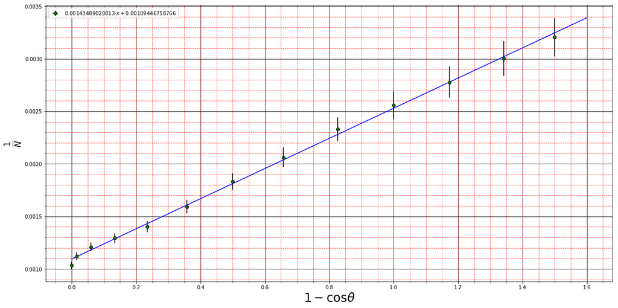

```python
xx = np.linspace(0, 1.6)
plt.figure(figsize=(20,10))
plt.errorbar(x, y,
        yerr=yerr,
        xerr=xerr,
        marker='o',
        color='k',
        ecolor='k',
        markerfacecolor='g',
        capsize=0,
        fmt='-',
        linestyle='None',
        label='{}$\cdot x +${}'.format(m, c))
plt.plot(xx, f(xx), 'b')
plt.legend()
plt.grid(b=True, which='major', color='k', linestyle='-')
plt.grid(b=True, which='minor', color='r', linestyle='--', alpha=0.75)
plt.xlabel(u'$1 - \cos$' + '$\\theta$', fontsize=24)
plt.ylabel(u'$\\frac{1}{N}$', fontsize=24)
plt.minorticks_on()
plt.savefig('graph.png')
plt.show()
```

```python
N0 = 1./f(0)
N90 = 1./f(1)
print('N(0) = {}\nN(90) = {}'.format(N0, N90))
```

```
N(0) = 913.686262867
N(90) = 395.357272769
```

```python
E_gamma = 662e3
mc2 = E_gamma * N90 / (N0 - N90)
print('E = {}кэВ'.format(mc2/1000))
```

```
E = 504.942844357кэВ
```